# 260-2016-11-02

2016-11-04 08:49:03

## Let it go…

[video not shown]

## Don't You Worry 'Bout a Thing

[video not shown]

## Today's topics

- Quiz 3
- Fear
- Stress

## Inducing "fear-like" behavior in animals

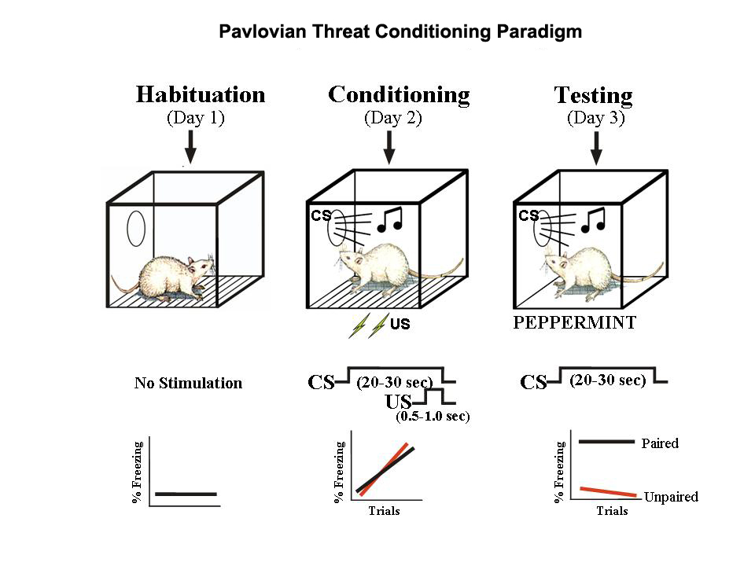

http://www.cns.nyu.edu/labs/ledouxlab/images/image_research/fear_conditioning.jpg

## Rat vs. Human

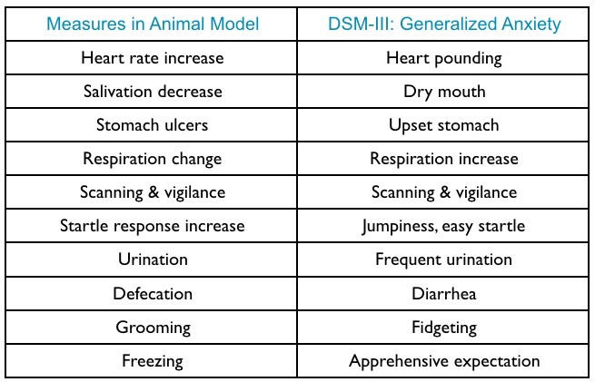

Adapted from (Davis 1992)

## Amygdala circuits

[figure not shown]

[(Medina et al. 2002)](http://dx.doi.org/10.1038/nrn728)

## Amygdala role

- Convergent inputs
  - Thalamus
  - Cerebral cortex
- Lesions of amygdala impair 'fear conditioning'
- Project to
  - CG (central gray matter) of tegmentum: behavior
  - LH (lateral hyp): ANS
  - PVN (paraventricular n. of hyp): hormones

## Cerebral cortex role

- Response discrimination?
  - Cortex lesions cause generalized not cue-specific fear response
- Fast, crude responses vs. slower, detailed ones
  - That’s a stick, not a snake!
  - Prefrontal cortex and response inhibition

## Emotion <==> Cognition?

[figure not shown]

[(Pessoa 2008)](http://dx.doi.org/10.1038/nrn2317)

## [(Pessoa 2008)](http://dx.doi.org/10.1038/nrn2317)

*Here, I will argue that complex cognitive–emotional behaviours have their basis in dynamic coalitions of networks of brain areas, none of which should be conceptualized as specifically affective or cognitive. Central to cognitive–emotional interactions are brain areas with a high degree of connectivity, called hubs, which are critical for regulating the flow and integration of information between regions.*

## Circuits for survival

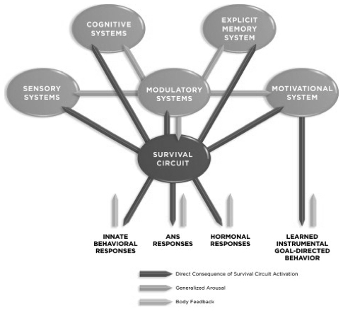

[(J. LeDoux 2012)](http://dx.doi.org/10.1016/j.neuron.2012.02.004)

## Emotion as global "state"

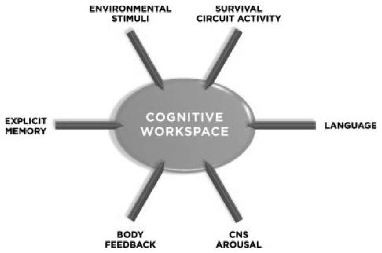

[(J. LeDoux 2012)](http://dx.doi.org/10.1016/j.neuron.2012.02.004)

## "Emotional" stimuli serve multiple roles

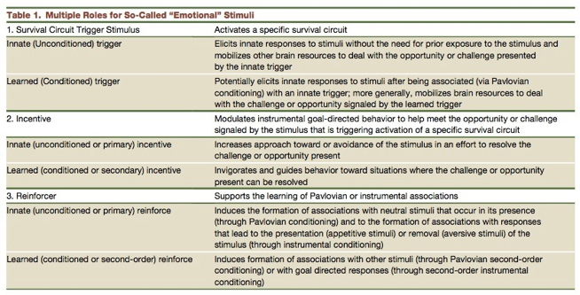

[(J. LeDoux 2012)](http://dx.doi.org/10.1016/j.neuron.2012.02.004)

## Biological imperatives and stress

- Sustenance
  - Hunger, thirst
- Well-being/defense
  - Threat

## Biological imperatives and stress

- Reproduction
  - Rejection
- Affiliation
  - Loneliness

## Stress and the brain

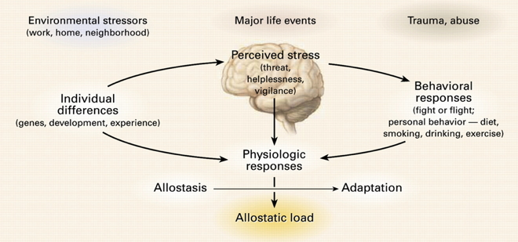

[(McEwen 2007)](http://dx.doi.org/10.1152/physrev.00041.2006)

## Brain under stress

- Brain detects threat
- Mobilizes physiological, behavioral responses
- Acute stress
  - Short duration
  - Fast action required
  - HPA (Cortisol), SAM (NE/Epi) axes
- vs. Chronic stress

## Glucocorticoids

- Adrenal cortex releases hormones
  - Cortisol (hydrocortisone)
    - Increases blood glucose levels
    - Suppresses immune system
    - Reduces inflammation
    - Aids in metabolism
  - Receptors in brain and body

## Cortisol and the brain

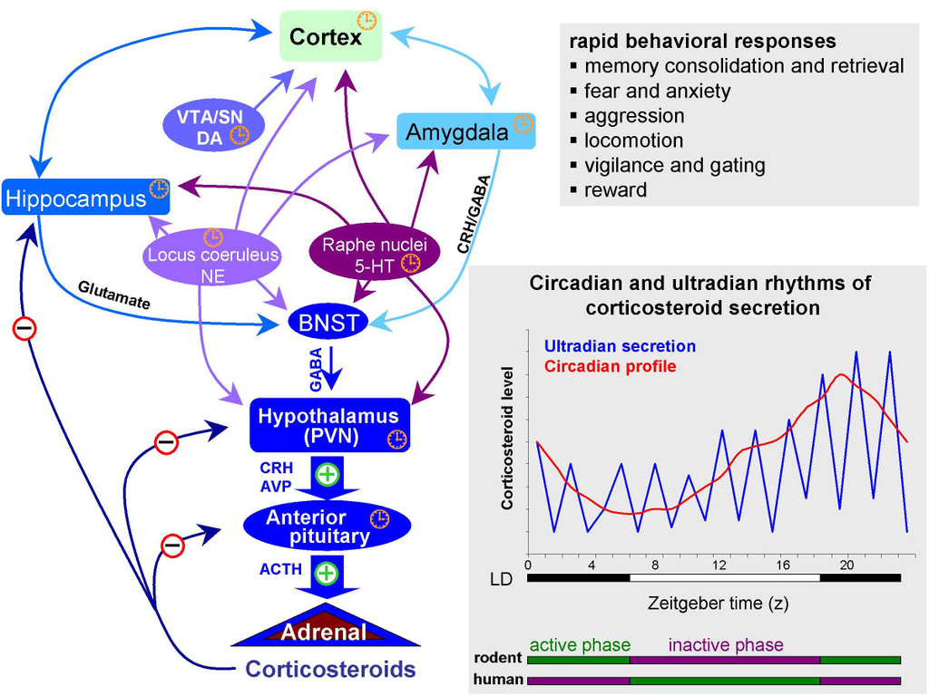

http://www.molecularbrain.com/content/figures/1756-6606-3-2-1-l.jpg

## Glucocorticoid cascade hypothesis

- Cort receptors in hip, amyg, hyp
- Hip regulates HPA axis via hyp
- Prolonged cortisol exposure reduces hip response
- Reduced volume, connectivity in hip
- Hip critical for long-term memory formation
- Chronic stress impairs long-term memory

## But, cortisol -> stress link not straightforward

[figure not shown]

[(Å. Faresjö et al. 2013)](http://dx.doi.org/10.1371/journal.pone.0073828)

## Let it go…

- Reaction to stress more important than its frequency [(Sin et al. 2016)](http://doi.org/10.1097/PSY.0000000000000306)
- *"…Individual differences in daily negative affect and responses to daily stressors were more strongly related to cardiovascular autonomic regulation than the frequency of such stressors."*

## [(Sin et al. 2016)](http://doi.org/10.1097/PSY.0000000000000306)

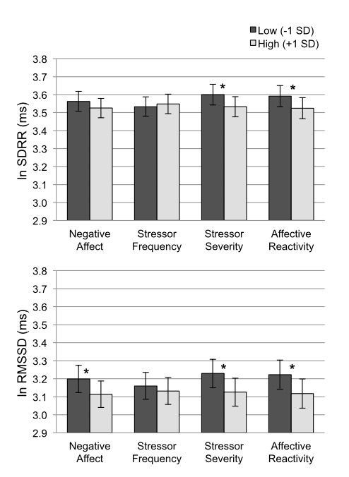

## Can Poverty Impede Cognitive Function?

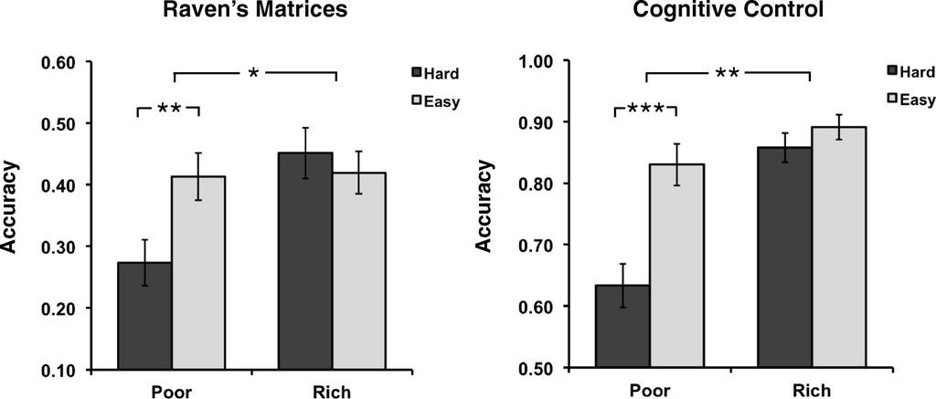

[(Mani et al. 2013)](http://dx.doi.org/10.1126/science.1238041)

## [(Mani et al. 2013)](http://dx.doi.org/10.1126/science.1238041)

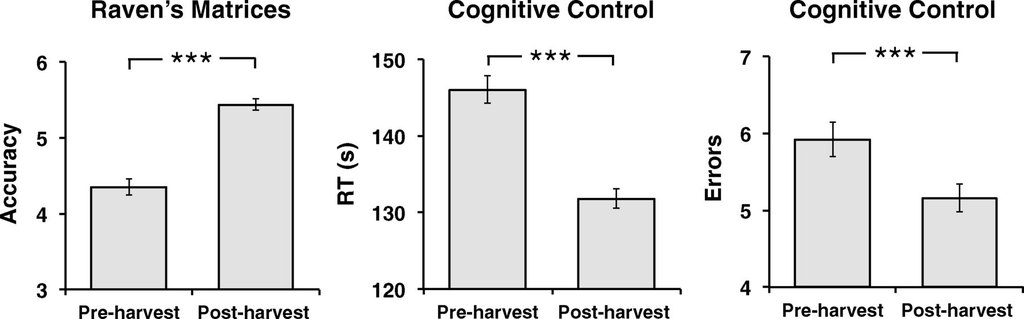

[(Mani et al. 2013)](http://dx.doi.org/10.1126/science.1238041)

## Stress and coping across the animal kingdom

- Pain thresholds lower (sensitivity greater) when a mouse's cage mate is also in pain
- Rats will cooperate to release distressed cage mage, foregoing food rewards
- [(Sapolsky 2016)](http://doi.org/10.1038/nn.4397)

## Why Zebras Don't Get Ulcers

[figure not shown]

## Your stress ain't like mine

- Phasic (short-term) vs. Chronic (long-term)
- Physical stress (hunger, thirst, injury, disease) vs. social stress

## Main points

- Biological approach to emotion
  - Behavior
  - Physiological states
  - Subjective feelings
  - Adaptive function
- Networks of brain systems, multiple NT systems

## Why Worry Now?

[video not shown]

## References

Davis, Michael. 1992. “The Role of the Amygdala in Fear-Potentiated Startle: Implications for Animal Models of Anxiety.” *Trends in Pharmacological Sciences* 13. Elsevier: 35–41. doi:10.1016/0165-6147(92)90014-W.

Faresjö, Åshild, Elvar Theodorsson, Marios Chatziarzenis, Vasiliki Sapouna, Hans-Peter Claesson, Jenny Koppner, and Tomas Faresjö. 2013. “Higher Perceived Stress but Lower Cortisol Levels Found Among Young Greek Adults Living in a Stressful Social Environment in Comparison with Swedish Young Adults.” *PLoS ONE* 8 (9): e73828. doi:10.1371/journal.pone.0073828.

LeDoux, Joseph. 2012. “Rethinking the Emotional Brain.” *Neuron* 73 (4): 653–76. doi:10.1016/j.neuron.2012.02.004.

Mani, Anandi, Sendhil Mullainathan, Eldar Shafir, and Jiaying Zhao. 2013. “Poverty Impedes Cognitive Function.” *Science* 341 (6149): 976–80. doi:10.1126/science.1238041.

McEwen, B. S. 2007. “Physiology and Neurobiology of Stress and Adaptation: Central Role of the Brain.” *Physiological Reviews* 87 (3): 873–904. doi:10.1152/physrev.00041.2006.

Medina, Javier F, J Christopher Repa, Michael D Mauk, and Joseph E LeDoux. 2002. “Parallels Between Cerebellum-and Amygdala-Dependent Conditioning.” *Nature Reviews Neuroscience* 3 (2). Nature Publishing Group: 122–31. doi:10.1038/nrn728.

Pessoa, Luiz. 2008. “On the Relationship Between Emotion and Cognition.” *Nature Reviews Neuroscience* 9 (2): 148–58. doi:10.1038/nrn2317.

Sapolsky, Robert M. 2016. “Psychiatric Distress in Animals Versus Animal Models of Psychiatric Distress.” *Nature Neuroscience* 19 (11): 1387–9. doi:10.1038/nn.4397.

Sin, Nancy L., Richard P. Sloan, Paula S. McKinley, and David M. Almeida. 2016. “Linking Daily Stress Processes and Laboratory-Based Heart Rate Variability in a National Sample of Midlife and Older Adults.” *Psychosomatic Medicine*, February. doi:10.1097/PSY.0000000000000306.